# Análisis Exploratorio de Datos Financieros para la Identificación de Estructuras Latentes en las Acciones de Microsoft (2000 - 2026)

## Diagnóstico de Residuales

El diagnóstico de residuales permite verificar si el modelo cumple los supuestos estadísticos requeridos. Para un modelo ARIMA correctamente especificado, los residuales deben comportarse como ruido blanco, es decir:

Media cero y varianza aproximadamente constante. Ausencia de autocorrelación (los residuales son independientes entre sí). Distribución aproximadamente normal (con posibles colas pesadas, típicas en finanzas).

### 1. Gráfico de residuales en el tiempo

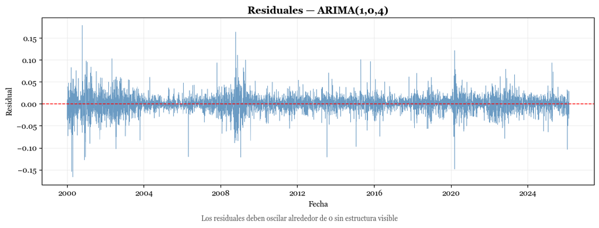

```python
import matplotlib.pyplot as plt

# Extraer residuales del modelo ajustado
residuals_model = best_model.resid
resid_dates     = returns_clean.index

resid_df = pd.DataFrame({
    'Date':     resid_dates,
    'Residual': residuals_model.values
})

# Gráfico
fig, ax = plt.subplots(figsize=(11, 4))

ax.plot(resid_df['Date'], resid_df['Residual'],
        color='steelblue', linewidth=0.4, alpha=0.8, label='Residual')
ax.axhline(0, linestyle='--', color='red', linewidth=1)

ax.set_title(f"Residuales — ARIMA({best_p},{best_d},{best_q})", fontsize=13, fontweight='bold')
ax.set_xlabel("Fecha")
ax.set_ylabel("Residual")
fig.text(0.5, -0.02,
         "Los residuales deben oscilar alrededor de 0 sin estructura visible",
         ha='center', fontsize=9, color='#555555')

ax.xaxis.set_major_locator(plt.matplotlib.dates.YearLocator(4))
ax.xaxis.set_major_formatter(plt.matplotlib.dates.DateFormatter('%Y'))
ax.grid(axis='both', color='#e0e0e0', linewidth=0.4)

plt.tight_layout()
plt.show()
```

### 2. ACF de residuales (Autocorrelación formal)

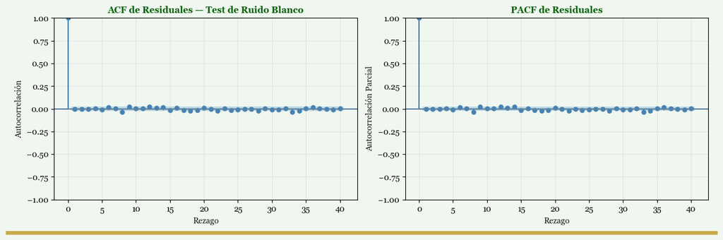

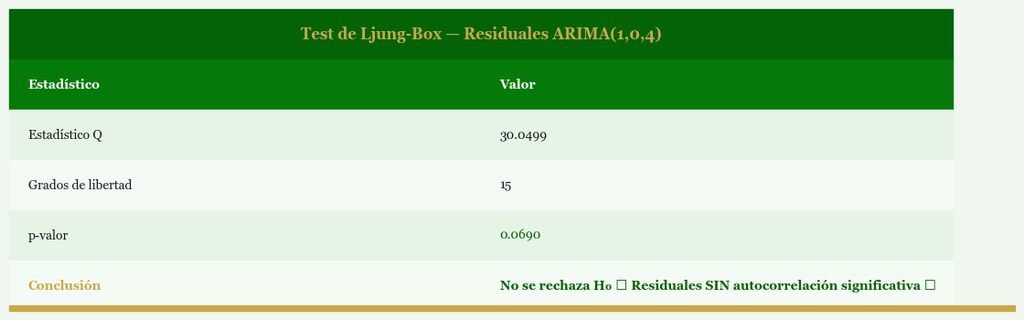

```python
import matplotlib.pyplot as plt
import matplotlib.patches as mpatches
from statsmodels.graphics.tsaplots import plot_acf, plot_pacf
from statsmodels.stats.diagnostic import acorr_ljungbox

plt.rcParams['font.family'] = 'Georgia'

C_HEADER = '#046307'
C_SUB    = '#057a09'
C_ROW1   = '#e6f4e6'
C_ROW2   = '#f4fbf4'
C_GOLD   = '#c9a84c'
C_TEXT   = '#1a1a1a'
C_WHITE  = 'white'
BG       = '#f0f7f0'

# ── ACF y PACF ────────────────────────────────────────────────────────────────
fig, (ax1, ax2) = plt.subplots(1, 2, figsize=(12, 4), facecolor=BG)
ax1.set_facecolor(BG)
ax2.set_facecolor(BG)

plot_acf(residuals_model, lags=40, ax=ax1, color='steelblue',
         vlines_kwargs={'colors': 'steelblue'})
ax1.set_title("ACF de Residuales — Test de Ruido Blanco",
              fontsize=11, fontweight='bold', color=C_HEADER)
ax1.set_xlabel("Rezago", color=C_TEXT)
ax1.set_ylabel("Autocorrelación", color=C_TEXT)
ax1.grid(color='#d0d8d0', linewidth=0.4)
ax1.axhline(0, color='gray', linewidth=0.5)

plot_pacf(residuals_model, lags=40, ax=ax2, color='steelblue',
          vlines_kwargs={'colors': 'steelblue'})
ax2.set_title("PACF de Residuales",
              fontsize=11, fontweight='bold', color=C_HEADER)
ax2.set_xlabel("Rezago", color=C_TEXT)
ax2.set_ylabel("Autocorrelación Parcial", color=C_TEXT)
ax2.grid(color='#d0d8d0', linewidth=0.4)
ax2.axhline(0, color='gray', linewidth=0.5)

fig.patch.set_facecolor(BG)
fig.patches.append(plt.Rectangle((0, 0), 1, 0.012,
    transform=fig.transFigure, color=C_GOLD, zorder=5))

plt.tight_layout()
plt.show()

# ── Test de Ljung-Box ─────────────────────────────────────────────────────────
lb_test = acorr_ljungbox(residuals_model, lags=20, return_df=True)
dof     = 20 - (best_p + best_q)
q_stat  = lb_test['lb_stat'].iloc[-1]
p_valor = lb_test['lb_pvalue'].iloc[-1]

conclusion = ("No se rechaza H₀ → Residuales SIN autocorrelación significativa ✓"
              if p_valor > 0.05 else
              "Se rechaza H₀ → Residuales CON autocorrelación residual ⚠")

filas = [
    ('Estadístico Q',     f'{q_stat:.4f}'),
    ('Grados de libertad',f'{dof}'),
    ('p-valor',           f'{p_valor:.4f}'),
    ('Conclusión',        conclusion),
]

# ── Tabla Ljung-Box ───────────────────────────────────────────────────────────
n_total = 1 + 1 + len(filas)
rh      = 1 / n_total
fig2, ax = plt.subplots(figsize=(11, max(3, n_total * 0.55)), facecolor=BG)
ax.set_facecolor(BG)
ax.axis('off')
ax.set_xlim(0, 1)
ax.set_ylim(0, 1)

def draw_row(ax, row_idx, bg, texto_izq, texto_der='',
             color_izq=None, color_der=None,
             bold_izq=False, bold_der=False,
             fontsize=10, center_izq=False):
    y_bottom = 1 - (row_idx + 1) * rh
    ax.add_patch(plt.Rectangle((0, y_bottom), 1, rh,
                 color=bg, transform=ax.transAxes, clip_on=False))
    ax.text(0.5 if center_izq else 0.02,
            y_bottom + rh / 2, texto_izq,
            transform=ax.transAxes,
            ha='center' if center_izq else 'left', va='center',
            fontsize=fontsize, color=color_izq or C_TEXT,
            fontweight='bold' if bold_izq else 'normal')
    if texto_der:
        ax.text(0.52, y_bottom + rh / 2, texto_der,
                transform=ax.transAxes, ha='left', va='center',
                fontsize=fontsize, color=color_der or C_TEXT,
                fontweight='bold' if bold_der else 'normal')

row = 0

# Título
draw_row(ax, row, C_HEADER,
         f'Test de Ljung-Box — Residuales ARIMA({best_p},{best_d},{best_q})',
         color_izq=C_GOLD, bold_izq=True, fontsize=12, center_izq=True)
row += 1

# Encabezado
draw_row(ax, row, C_SUB, 'Estadístico', 'Valor',
         color_izq=C_WHITE, color_der=C_WHITE, bold_izq=True, bold_der=True)
row += 1

# Filas
for etiqueta, valor in filas:
    bg       = C_ROW1 if row % 2 == 0 else C_ROW2
    es_conc  = etiqueta == 'Conclusión'
    es_pval  = etiqueta == 'p-valor'
    d_color  = (C_GOLD if p_valor < 0.05 else '#046307') if (es_conc or es_pval) else C_TEXT
    draw_row(ax, row, bg, etiqueta, valor,
             color_der=d_color, bold_der=es_conc,
             color_izq=C_GOLD if es_conc else C_TEXT,
             bold_izq=es_conc)
    row += 1

fig2.patches.append(plt.Rectangle((0, 0), 1, 0.018,
    transform=fig2.transFigure, color=C_GOLD, zorder=5))

plt.tight_layout(pad=0)
plt.show()
```

Los residuales del modelo ARIMA(1,0,4)\text{ARIMA}(1,0,4) ARIMA(1,0,4) superan satisfactoriamente el diagnóstico de independencia serial: la ACF y PACF no exhiben coeficientes significativos fuera de las bandas ±1.96/T\pm 1.96/\sqrt{T} ±1.96/T en ninguno de los 40 rezagos evaluados, y el test de Ljung-Box arroja Q(20)=30.05Q(20) = 30.05 Q(20)=30.05 con p=0.069>0.05p = 0.069 > 0.05 p=0.069>0.05, de modo que no se rechaza H0:ρ1=ρ2=⋯=ρ20=0H_0: \rho_1 = \rho_2 = \cdots = \rho_{20} = 0 H0:ρ1=ρ2=⋯=ρ20=0 al nivel convencional del 5%. Este resultado implica que el modelo captura íntegramente la estructura de autocorrelación lineal presente en la serie de retornos logarítmicos de MSFT, y que los residuales constituyen una aproximación empíricamente válida a un proceso de innovaciones no correlacionadas, condición necesaria para la consistencia de los estimadores de Máxima Verosimilitud y para la validez de los intervalos de confianza del pronóstico. No obstante, es importante señalar que la ausencia de autocorrelación serial no implica independencia estricta: como evidencian el rechazo de la prueba de Jarque-Bera y la heterocedasticidad condicional detectada mediante ARCH-LM, los residuales presentan dependencia en sus momentos de orden superior, fenómeno que escapa al poder diagnóstico de la prueba de Ljung-Box y que constituye la motivación estadística para extender la especificación hacia un modelo ARIMA(1,0,4)-GARCH(1,1)\text{ARIMA}(1,0,4)\text{-GARCH}(1,1) ARIMA(1,0,4)-GARCH(1,1).

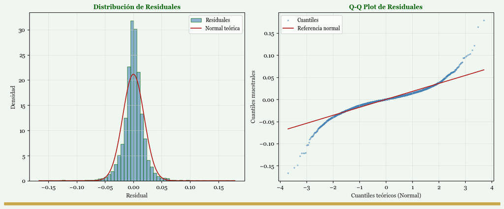

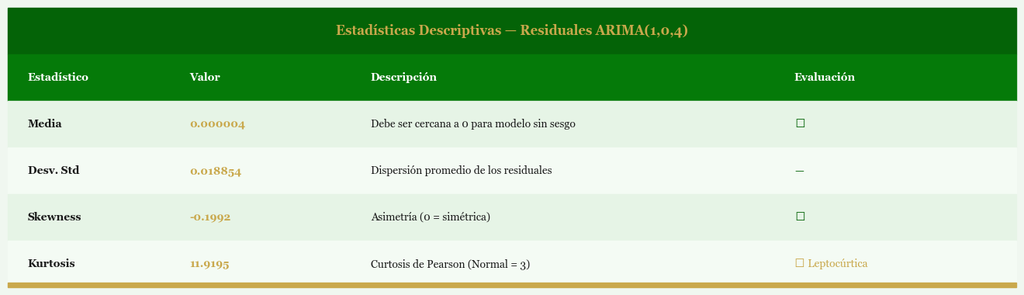

```python
import numpy as np
import matplotlib.pyplot as plt
import scipy.stats as stats

plt.rcParams['font.family'] = 'Georgia'

C_HEADER = '#046307'
C_SUB    = '#057a09'
C_ROW1   = '#e6f4e6'
C_ROW2   = '#f4fbf4'
C_GOLD   = '#c9a84c'
C_TEXT   = '#1a1a1a'
C_WHITE  = 'white'
BG       = '#f0f7f0'

# ── Cálculo ───────────────────────────────────────────────────────────────────
resid_vec = residuals_model.values
mu_r      = resid_vec.mean()
sd_r      = resid_vec.std()
skewness  = stats.skew(resid_vec)
kurtosis  = stats.kurtosis(resid_vec, fisher=False)

# ── Gráficos ──────────────────────────────────────────────────────────────────
fig, (ax1, ax2) = plt.subplots(1, 2, figsize=(12, 5), facecolor=BG)
ax1.set_facecolor(BG)
ax2.set_facecolor(BG)

# Histograma + curva normal
x_norm = np.linspace(resid_vec.min(), resid_vec.max(), 300)
y_norm = stats.norm.pdf(x_norm, loc=mu_r, scale=sd_r)

ax1.hist(resid_vec, bins=60, density=True,
         alpha=0.6, color='steelblue', edgecolor='#046307', label='Residuales')
ax1.plot(x_norm, y_norm,
         color='firebrick', linewidth=1.5, label='Normal teórica')
ax1.set_title("Distribución de Residuales",
              fontsize=11, fontweight='bold', color=C_HEADER)
ax1.set_xlabel("Residual", color=C_TEXT)
ax1.set_ylabel("Densidad",  color=C_TEXT)
ax1.legend(fontsize=9)
ax1.grid(color='#d0d8d0', linewidth=0.4)

# Q-Q Plot
(osm, osr), (slope, intercept, _) = stats.probplot(resid_vec, dist='norm')
ax2.scatter(osm, osr, color='steelblue', alpha=0.4, s=4, label='Cuantiles')
ax2.plot(osm, slope * np.array(osm) + intercept,
         color='firebrick', linewidth=1.5, label='Referencia normal')
ax2.set_title("Q-Q Plot de Residuales",
              fontsize=11, fontweight='bold', color=C_HEADER)
ax2.set_xlabel("Cuantiles teóricos (Normal)", color=C_TEXT)
ax2.set_ylabel("Cuantiles muestrales",        color=C_TEXT)
ax2.legend(fontsize=9)
ax2.grid(color='#d0d8d0', linewidth=0.4)

fig.patch.set_facecolor(BG)
fig.patches.append(plt.Rectangle((0, 0), 1, 0.012,
    transform=fig.transFigure, color=C_GOLD, zorder=5))

plt.tight_layout()
plt.show()

# ── Tabla estadísticas descriptivas ──────────────────────────────────────────
filas = [
    ('Media',     f'{mu_r:.6f}',    'Debe ser cercana a 0 para modelo sin sesgo',
     '✓' if abs(mu_r) < 0.001 else '⚠'),
    ('Desv. Std', f'{sd_r:.6f}',    'Dispersión promedio de los residuales', '—'),
    ('Skewness',  f'{skewness:.4f}','Asimetría (0 = simétrica)',
     '✓' if abs(skewness) < 0.5 else '⚠ Asimétrica'),
    ('Kurtosis',  f'{kurtosis:.4f}','Curtosis de Pearson (Normal = 3)',
     '⚠ Leptocúrtica' if kurtosis > 5 else '✓'),
]

n_total = 1 + 1 + len(filas)
rh      = 1 / n_total
fig2, ax = plt.subplots(figsize=(13, max(3.5, n_total * 0.6)), facecolor=BG)
ax.set_facecolor(BG)
ax.axis('off')
ax.set_xlim(0, 1)
ax.set_ylim(0, 1)

x_cols = [0.02, 0.18, 0.36, 0.78]

def draw_row(ax, row_idx, bg, cols, colors=None, bolds=None, fontsize=10, center=False):
    y_bottom = 1 - (row_idx + 1) * rh
    ax.add_patch(plt.Rectangle((0, y_bottom), 1, rh,
                 color=bg, transform=ax.transAxes, clip_on=False))
    for i, (txt, x) in enumerate(zip(cols, x_cols)):
        ax.text(0.5 if (center and i == 0 and len(cols) == 1) else x,
                y_bottom + rh / 2, str(txt),
                transform=ax.transAxes,
                ha='center' if (center and i == 0) else 'left',
                va='center', fontsize=fontsize,
                color=colors[i] if colors else C_TEXT,
                fontweight='bold' if (bolds and bolds[i]) else 'normal')

row = 0

# Título
y_bottom = 1 - rh
ax.add_patch(plt.Rectangle((0, y_bottom), 1, rh,
             color=C_HEADER, transform=ax.transAxes, clip_on=False))
ax.text(0.5, y_bottom + rh / 2,
        f'Estadísticas Descriptivas — Residuales ARIMA({best_p},{best_d},{best_q})',
        transform=ax.transAxes, ha='center', va='center',
        fontsize=12, color=C_GOLD, fontweight='bold')
row += 1

# Encabezado
draw_row(ax, row, C_SUB,
         ['Estadístico', 'Valor', 'Descripción', 'Evaluación'],
         colors=[C_WHITE]*4, bolds=[True]*4)
row += 1

# Filas
for estadistico, valor, desc, evaluacion in filas:
    bg      = C_ROW1 if row % 2 == 0 else C_ROW2
    e_color = C_GOLD if '⚠' in evaluacion else '#046307'
    draw_row(ax, row, bg,
             [estadistico, valor, desc, evaluacion],
             colors=[C_TEXT, C_GOLD, C_TEXT, e_color],
             bolds=[True, True, False, False])
    row += 1

fig2.patches.append(plt.Rectangle((0, 0), 1, 0.018,
    transform=fig2.transFigure, color=C_GOLD, zorder=5))

plt.tight_layout(pad=0)
plt.show()
```

### 5. Test de Jarque-Bera (normalidad formal)

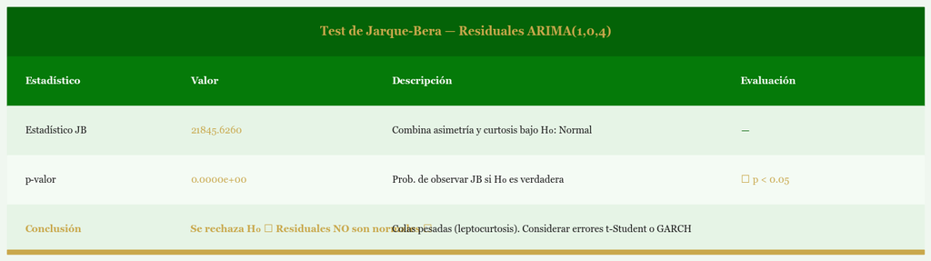

```python
from scipy.stats import jarque_bera
import matplotlib.pyplot as plt

plt.rcParams['font.family'] = 'Georgia'

C_HEADER = '#046307'
C_SUB    = '#057a09'
C_ROW1   = '#e6f4e6'
C_ROW2   = '#f4fbf4'
C_GOLD   = '#c9a84c'
C_TEXT   = '#1a1a1a'
C_WHITE  = 'white'
BG       = '#f0f7f0'

# ── Test de Jarque-Bera ───────────────────────────────────────────────────────
jb_stat, jb_pval = jarque_bera(resid_vec)

if jb_pval > 0.05:
    conclusion = "No se rechaza H₀ → Residuales aproximadamente normales ✓"
    nota       = "—"
else:
    conclusion = "Se rechaza H₀ → Residuales NO son normales ⚠"
    nota       = "Colas pesadas (leptocurtosis). Considerar errores t-Student o GARCH"

filas = [
    ('Estadístico JB', f'{jb_stat:.4f}',
     'Combina asimetría y curtosis bajo H₀: Normal', '—'),
    ('p-valor',        f'{jb_pval:.4e}',
     'Prob. de observar JB si H₀ es verdadera',
     '✓ p > 0.05' if jb_pval > 0.05 else '⚠ p < 0.05'),
    ('Conclusión',     conclusion, nota, ''),
]

# ── Tabla ─────────────────────────────────────────────────────────────────────
n_total = 1 + 1 + len(filas)
rh      = 1 / n_total
fig, ax = plt.subplots(figsize=(13, max(3.5, n_total * 0.65)), facecolor=BG)
ax.set_facecolor(BG)
ax.axis('off')
ax.set_xlim(0, 1)
ax.set_ylim(0, 1)

x_cols = [0.02, 0.20, 0.42, 0.80]

def draw_row(ax, row_idx, bg, cols, colors=None, bolds=None, fontsize=10):
    y_bottom = 1 - (row_idx + 1) * rh
    ax.add_patch(plt.Rectangle((0, y_bottom), 1, rh,
                 color=bg, transform=ax.transAxes, clip_on=False))
    for i, (txt, x) in enumerate(zip(cols, x_cols)):
        ax.text(x, y_bottom + rh / 2, str(txt),
                transform=ax.transAxes,
                ha='left', va='center', fontsize=fontsize,
                color=colors[i] if colors else C_TEXT,
                fontweight='bold' if (bolds and bolds[i]) else 'normal')

row = 0

# Título
y_bottom = 1 - rh
ax.add_patch(plt.Rectangle((0, y_bottom), 1, rh,
             color=C_HEADER, transform=ax.transAxes, clip_on=False))
ax.text(0.5, y_bottom + rh / 2,
        f'Test de Jarque-Bera — Residuales ARIMA({best_p},{best_d},{best_q})',
        transform=ax.transAxes, ha='center', va='center',
        fontsize=12, color=C_GOLD, fontweight='bold')
row += 1

# Encabezado
draw_row(ax, row, C_SUB,
         ['Estadístico', 'Valor', 'Descripción', 'Evaluación'],
         colors=[C_WHITE]*4, bolds=[True]*4)
row += 1

# Filas
for estadistico, valor, desc, evaluacion in filas:
    bg        = C_ROW1 if row % 2 == 0 else C_ROW2
    es_conc   = estadistico == 'Conclusión'
    es_pval   = estadistico == 'p-valor'
    v_color   = C_GOLD if (es_conc or es_pval) else C_GOLD
    e_color   = C_GOLD if '⚠' in evaluacion else '#046307'
    i_color   = C_GOLD if es_conc else C_TEXT

    draw_row(ax, row, bg,
             [estadistico, valor, desc, evaluacion],
             colors=[i_color, v_color, C_TEXT, e_color],
             bolds=[es_conc, es_conc, False, False])
    row += 1

fig.patches.append(plt.Rectangle((0, 0), 1, 0.018,
    transform=fig.transFigure, color=C_GOLD, zorder=5))

plt.tight_layout(pad=0)
plt.show()
```

Este hallazgo es coherente con la inspección gráfica previa del histograma y del Q-Q plot, donde se observaban desviaciones en los cuantiles extremos. En términos econométricos, la no normalidad de los residuos no invalida la capacidad predictiva del modelo ARIMA, pero sí sugiere que la estructura de volatilidad no está completamente capturada bajo el supuesto de varianza constante. En consecuencia, desde una perspectiva metodológica, se recomienda considerar extensiones que modelen explícitamente la heterocedasticidad condicional, como modelos con innovaciones t-Student o la incorporación de modelos de volatilidad tipo GARCH, con el fin de capturar de manera más adecuada la dinámica de los shocks extremos característica de los mercados financieros.

## Resumen del Proceso de Modelamiento

[figure not shown]

```python
import matplotlib.pyplot as plt

plt.rcParams['font.family'] = 'Georgia'

C_HEADER = '#046307'
C_SUB    = '#057a09'
C_ROW1   = '#e6f4e6'
C_ROW2   = '#f4fbf4'
C_GOLD   = '#c9a84c'
C_TEXT   = '#1a1a1a'
C_WHITE  = 'white'
BG       = '#f0f7f0'

# ── Secciones ─────────────────────────────────────────────────────────────────
seccion1 = [
    ('Serie modelada',   'Retornos logarítmicos diarios'),
    ('Observaciones',    f'{n_total} (train: {train_size} | test: {test_size})'),
    ('Mejor modelo',     f'ARIMA({best_p}, {best_d}, {best_q})'),
    ('AIC',              f'{best_aic:.4f}'),
]

seccion2 = [
    ('MAE',              f'{MAE:.6f}'),
    ('RMSE',             f'{RMSE:.6f}'),
    ('MAPE',             f'{MAPE:.2f}%'),
    ('Directional Acc.', f'{DA:.2f}%'),
]

seccion3 = [
    ('Ljung-Box p-valor', f'{p_valor:.4f}',
     '✓ Ruido blanco'    if p_valor > 0.05 else '⚠ Autocorrelación'),
    ('JB p-valor',        f'{jb_pval:.2e}',
     '✓ Normal'          if jb_pval > 0.05 else '⚠ No normal (leptocúrtica)'),
]

# ── Dimensiones ───────────────────────────────────────────────────────────────
n_total_rows = (1 + 1 + len(seccion1) +
                1 + 1 + len(seccion2) +
                1 + 1 + len(seccion3))
rh    = 1 / n_total_rows
fig_h = max(6, n_total_rows * 0.52)

fig, ax = plt.subplots(figsize=(13, fig_h), facecolor=BG)
ax.set_facecolor(BG)
ax.axis('off')
ax.set_xlim(0, 1)
ax.set_ylim(0, 1)

x_izq = 0.03
x_der = 0.45
x_ev  = 0.75

def draw_row(ax, row_idx, bg, texto_izq, texto_der='', texto_ev='',
             color_izq=None, color_der=None, color_ev=None,
             bold_izq=False, bold_der=False,
             fontsize=10, center_izq=False):
    y_bottom = 1 - (row_idx + 1) * rh
    ax.add_patch(plt.Rectangle((0, y_bottom), 1, rh,
                 color=bg, transform=ax.transAxes, clip_on=False))
    ax.text(0.5 if center_izq else x_izq,
            y_bottom + rh / 2, texto_izq,
            transform=ax.transAxes,
            ha='center' if center_izq else 'left', va='center',
            fontsize=fontsize, color=color_izq or C_TEXT,
            fontweight='bold' if bold_izq else 'normal')
    if texto_der:
        ax.text(x_der, y_bottom + rh / 2, texto_der,
                transform=ax.transAxes, ha='left', va='center',
                fontsize=fontsize, color=color_der or C_TEXT,
                fontweight='bold' if bold_der else 'normal')
    if texto_ev:
        ax.text(x_ev, y_bottom + rh / 2, texto_ev,
                transform=ax.transAxes, ha='left', va='center',
                fontsize=fontsize - 0.5,
                color=color_ev or C_TEXT)

row = 0

# ── TÍTULO PRINCIPAL ──────────────────────────────────────────────────────────
draw_row(ax, row, C_HEADER,
         'RESUMEN — MODELAMIENTO ARIMA (MSFT)',
         color_izq=C_GOLD, bold_izq=True,
         fontsize=13, center_izq=True)
row += 1

# ── SECCIÓN 1: INFO GENERAL ───────────────────────────────────────────────────
draw_row(ax, row, C_SUB,
         'Configuración del Modelo', 'Valor',
         color_izq=C_WHITE, color_der=C_WHITE,
         bold_izq=True, bold_der=True)
row += 1

for etiqueta, valor in seccion1:
    bg = C_ROW1 if row % 2 == 0 else C_ROW2
    draw_row(ax, row, bg, etiqueta, valor,
             color_der=C_GOLD, bold_der=True)
    row += 1

# ── SECCIÓN 2: MÉTRICAS ───────────────────────────────────────────────────────
draw_row(ax, row, C_SUB,
         'Métricas de Precisión — Rolling Forecast', 'Valor',
         color_izq=C_WHITE, color_der=C_WHITE,
         bold_izq=True, bold_der=True)
row += 1

for etiqueta, valor in seccion2:
    bg      = C_ROW1 if row % 2 == 0 else C_ROW2
    is_da   = 'Directional' in etiqueta
    is_mape = 'MAPE' in etiqueta
    v_color = C_GOLD if (is_da or is_mape) else '#046307'
    draw_row(ax, row, bg, etiqueta, valor,
             color_der=v_color, bold_der=True)
    row += 1

# ── SECCIÓN 3: DIAGNÓSTICO ────────────────────────────────────────────────────
draw_row(ax, row, C_SUB,
         'Diagnóstico de Residuales', 'p-valor', 'Evaluación',
         color_izq=C_WHITE, color_der=C_WHITE, color_ev=C_WHITE,
         bold_izq=True, bold_der=True)
row += 1

for etiqueta, valor, evaluacion in seccion3:
    bg      = C_ROW1 if row % 2 == 0 else C_ROW2
    e_color = C_GOLD if '⚠' in evaluacion else '#046307'
    draw_row(ax, row, bg, etiqueta, valor, evaluacion,
             color_der=C_GOLD, color_ev=e_color, bold_der=True)
    row += 1

# ── LÍNEA DORADA INFERIOR ─────────────────────────────────────────────────────
fig.patches.append(plt.Rectangle((0, 0), 1, 0.014,
    transform=fig.transFigure, color=C_GOLD, zorder=5))

plt.tight_layout(pad=0)
plt.show()
```

```python
df = pd.read_csv(r'C:\Users\gopau\OneDrive\Desktop\DATAVIZ\Dash\MSFT_dash\data\MSFT.csv', index_col=0, parse_dates=True)
```

```
Tipo: <class 'numpy.ndarray'> | Shape: (6602,) | dtype: float64
Obs: 6602 | Min: 11.11 | Max: 539.83
```

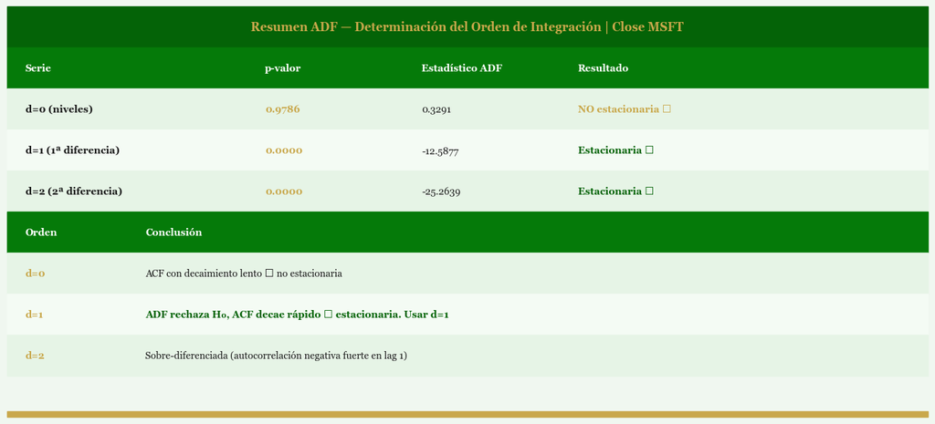

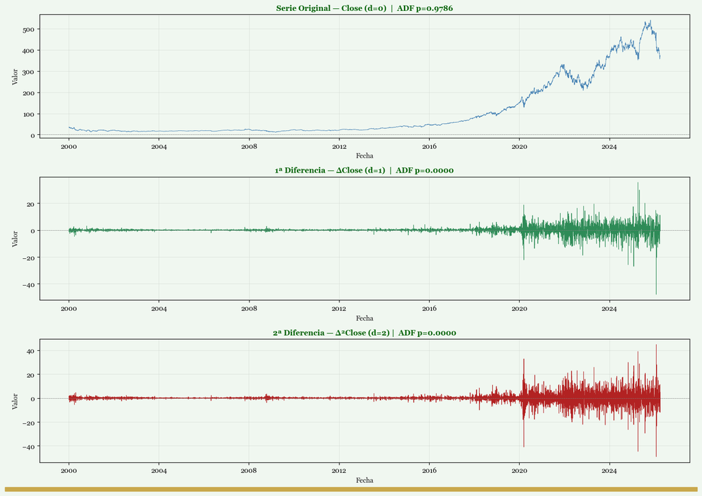

```python
import numpy as np
import matplotlib.pyplot as plt
from statsmodels.tsa.stattools import adfuller

plt.rcParams['font.family'] = 'Georgia'

C_HEADER = '#046307'
C_SUB    = '#057a09'
C_ROW1   = '#e6f4e6'
C_ROW2   = '#f4fbf4'
C_GOLD   = '#c9a84c'
C_TEXT   = '#1a1a1a'
C_WHITE  = 'white'
BG       = '#f0f7f0'

# ── 1. Extraer serie ──────────────────────────────────────────────────────────
close     = df['Close'].dropna()
close_vec = close.values.astype(float)
dates     = close.index

print(f"Tipo: {type(close_vec)} | Shape: {close_vec.shape} | dtype: {close_vec.dtype}")
print(f"Obs: {len(close_vec)} | Min: {close_vec.min():.2f} | Max: {close_vec.max():.2f}")

# ── 2. Series diferenciadas ───────────────────────────────────────────────────
close_d1 = np.diff(close_vec, n=1).astype(float)
close_d2 = np.diff(close_vec, n=2).astype(float)
dates_d0, dates_d1, dates_d2 = dates, dates[1:], dates[2:]

# ── 3. ADF por nivel ──────────────────────────────────────────────────────────
adf_d0 = adfuller(close_vec)
adf_d1 = adfuller(close_d1)
adf_d2 = adfuller(close_d2)

# ── 4. Tabla ADF ──────────────────────────────────────────────────────────────
filas_adf = [
    ('d=0 (niveles)',       f'{adf_d0[1]:.4f}', f'{adf_d0[0]:.4f}',
     'NO estacionaria ✗' if adf_d0[1] > 0.05 else 'Estacionaria ✓'),
    ('d=1 (1ª diferencia)', f'{adf_d1[1]:.4f}', f'{adf_d1[0]:.4f}',
     'NO estacionaria ✗' if adf_d1[1] > 0.05 else 'Estacionaria ✓'),
    ('d=2 (2ª diferencia)', f'{adf_d2[1]:.4f}', f'{adf_d2[0]:.4f}',
     'NO estacionaria ✗' if adf_d2[1] > 0.05 else 'Estacionaria ✓'),
]

concl_filas = [
    ('d=0', 'ACF con decaimiento lento → no estacionaria'),
    ('d=1', 'ADF rechaza H₀, ACF decae rápido → estacionaria. Usar d=1'),
    ('d=2', 'Sobre-diferenciada (autocorrelación negativa fuerte en lag 1)'),
]

n_total_rows = 1 + 1 + len(filas_adf) + 1 + 1 + len(concl_filas)
rh    = 1 / n_total_rows
fig_h = max(5, n_total_rows * 0.58)

fig_t, ax = plt.subplots(figsize=(13, fig_h), facecolor=BG)
ax.set_facecolor(BG)
ax.axis('off')
ax.set_xlim(0, 1)
ax.set_ylim(0, 1)

x_cols_adf  = [0.02, 0.28, 0.45, 0.62]
x_cols_conc = [0.02, 0.15]

def draw_row_multi(ax, row_idx, bg, cols, xs, colors=None, bolds=None,
                   fontsize=10, center_title=False):
    y_bottom = 1 - (row_idx + 1) * rh
    ax.add_patch(plt.Rectangle((0, y_bottom), 1, rh,
                 color=bg, transform=ax.transAxes, clip_on=False))
    if center_title:
        ax.text(0.5, y_bottom + rh / 2, cols[0],
                transform=ax.transAxes, ha='center', va='center',
                fontsize=fontsize, color=colors[0] if colors else C_TEXT,
                fontweight='bold' if (bolds and bolds[0]) else 'normal')
        return
    for i, (txt, x) in enumerate(zip(cols, xs)):
        ax.text(x, y_bottom + rh / 2, str(txt),
                transform=ax.transAxes, ha='left', va='center',
                fontsize=fontsize,
                color=colors[i] if colors else C_TEXT,
                fontweight='bold' if (bolds and bolds[i]) else 'normal')

row = 0

# Título
draw_row_multi(ax, row, C_HEADER,
               ['Resumen ADF — Determinación del Orden de Integración | Close MSFT'],
               x_cols_adf, colors=[C_GOLD], bolds=[True],
               fontsize=12, center_title=True)
row += 1

# Encabezado ADF
draw_row_multi(ax, row, C_SUB,
               ['Serie', 'p-valor', 'Estadístico ADF', 'Resultado'],
               x_cols_adf,
               colors=[C_WHITE]*4, bolds=[True]*4)
row += 1

# Filas ADF
for serie, pval, stat, resultado in filas_adf:
    bg      = C_ROW1 if row % 2 == 0 else C_ROW2
    r_color = C_GOLD if '✗' in resultado else '#046307'
    draw_row_multi(ax, row, bg,
                   [serie, pval, stat, resultado],
                   x_cols_adf,
                   colors=[C_TEXT, C_GOLD, C_TEXT, r_color],
                   bolds=[True, True, False, True])
    row += 1

# Encabezado conclusión
draw_row_multi(ax, row, C_SUB,
               ['Orden', 'Conclusión'],
               x_cols_conc,
               colors=[C_WHITE]*2, bolds=[True]*2)
row += 1

# Filas conclusión
for orden, conclusion in concl_filas:
    bg      = C_ROW1 if row % 2 == 0 else C_ROW2
    c_color = '#046307' if 'd=1' in orden else C_TEXT
    draw_row_multi(ax, row, bg,
                   [orden, conclusion],
                   x_cols_conc,
                   colors=[C_GOLD, c_color],
                   bolds=[True, 'd=1' in orden])
    row += 1

fig_t.patches.append(plt.Rectangle((0, 0), 1, 0.014,
    transform=fig_t.transFigure, color=C_GOLD, zorder=5))
plt.tight_layout(pad=0)
plt.show()

# ── 5. Gráficos de series ─────────────────────────────────────────────────────
datasets = [
    (dates_d0, close_vec, f'Serie Original — Close (d=0)  |  ADF p={adf_d0[1]:.4f}', 'steelblue'),
    (dates_d1, close_d1,  f'1ª Diferencia — ΔClose (d=1)  |  ADF p={adf_d1[1]:.4f}', 'seagreen'),
    (dates_d2, close_d2,  f'2ª Diferencia — Δ²Close (d=2) |  ADF p={adf_d2[1]:.4f}', 'firebrick'),
]

fig2, axes = plt.subplots(3, 1, figsize=(14, 10), facecolor=BG)

for ax, (dates_arr, values, title, color) in zip(axes, datasets):
    ax.set_facecolor(BG)
    ax.plot(dates_arr, values, color=color, linewidth=0.6)
    ax.axhline(0, linestyle='--', color='gray', linewidth=0.5)
    ax.set_title(title, fontsize=11, fontweight='bold', color=C_HEADER)
    ax.set_xlabel("Fecha", color=C_TEXT)
    ax.set_ylabel("Valor",  color=C_TEXT)
    ax.grid(color='#d0d8d0', linewidth=0.4)

fig2.patch.set_facecolor(BG)
fig2.patches.append(plt.Rectangle((0, 0), 1, 0.008,
    transform=fig2.transFigure, color=C_GOLD, zorder=5))

plt.tight_layout()
plt.show()
```

La gráfica de la serie original muestra una marcada tendencia creciente de largo plazo y cambios notorios en la volatilidad, características que sugieren la presencia de raíz unitaria. Este resultado se confirma formalmente mediante la prueba de Dickey–Fuller aumentada (ADF), cuyo estadístico de 0.3291 y p-valor de 0.9786 impiden rechazar la hipótesis nula de raíz unitaria. En consecuencia, se concluye que la serie en niveles no es estacionaria y requiere diferenciación antes de ser modelada con ARIMA.

Tras aplicar la primera diferencia, la serie resultante muestra fluctuaciones alrededor de una media cercana a cero y una reducción significativa de la tendencia determinística, lo cual indica que la transformación elimina la componente de crecimiento de largo plazo. La prueba ADF aplicada a la primera diferencia arroja un p-valor igual a 0.0000, permitiendo rechazar la hipótesis nula y concluir que la serie se vuelve estacionaria en media tras una diferenciación. La segunda diferencia también resulta estacionaria; sin embargo, dado que la estacionariedad ya se alcanza con una sola diferenciación, aplicar una segunda diferencia podría inducir sobrediferenciación y aumentar innecesariamente la varianza del proceso.

## Visualización del Rolling Forecast

```
Datos cargados: (6602, 5) | Columnas: ['Close', 'High', 'Low', 'Open', 'Volume']
Train: 5281 obs | Test: 1321 obs
Test desde: 2020-12-29 hasta: 2026-04-02
Modelo: ARIMA(0,1,1)
Ejecutando 1321 iteraciones...
  200/1321 completadas
  400/1321 completadas
  600/1321 completadas
  800/1321 completadas
  1000/1321 completadas
  1200/1321 completadas
Rolling Forecast completado.
Cobertura IC 95%: 40.0%
Cobertura IC 68%: 25.0%
```

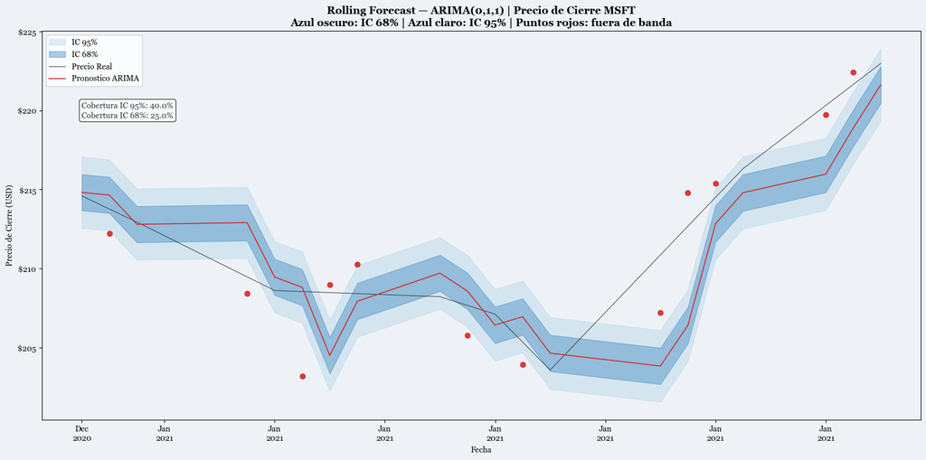

```python
import pandas as pd
import numpy as np
import matplotlib.pyplot as plt
import matplotlib.ticker as mtick
import warnings
warnings.filterwarnings('ignore')
from statsmodels.tsa.arima.model import ARIMA

# ── 1. Cargar datos ───────────────────────────────────────────────────────────
import os
os.chdir(r'C:\Users\gopau\OneDrive\Desktop\DATAVIZ\Dash\MSFT_dash')

df = pd.read_csv('data/MSFT.csv', index_col=0, parse_dates=True)
df.sort_index(inplace=True)
print(f"Datos cargados: {df.shape} | Columnas: {df.columns.tolist()}")

# ── 2. Serie Close limpia ─────────────────────────────────────────────────────
close_series  = df['Close'].dropna()
close_vec     = close_series.values.astype(float)
close_dates   = close_series.index

# ── 3. Split 80/20 ────────────────────────────────────────────────────────────
n_close       = len(close_series)
train_size_c  = int(np.floor(0.80 * n_close))
test_size_c   = n_close - train_size_c

train_close   = close_series.iloc[:train_size_c]
test_close    = close_series.iloc[train_size_c:]
dates_train_c = train_close.index
dates_test_c  = test_close.index          # ← variable que faltaba

actual_close_roll = test_close.values.astype(float)

print(f"Train: {train_size_c} obs | Test: {test_size_c} obs")
print(f"Test desde: {dates_test_c[0].date()} hasta: {dates_test_c[-1].date()}")

# ── 4. Parámetros del modelo (BIC ganador) ────────────────────────────────────
bp, bd, bq = 0, 1, 1    # ajusta si tu búsqueda dio otro resultado
print(f"Modelo: ARIMA({bp},{bd},{bq})")

# ── 5. Rolling Forecast con IC ────────────────────────────────────────────────
# NOTA: tarda varios minutos
fc_roll_c = []; fc_lo95 = []; fc_hi95 = []; fc_lo68 = []; fc_hi68 = []
modelo_roll_c = None

print(f"Ejecutando {test_size_c} iteraciones...")
for i in range(test_size_c):
    train_w = close_series.iloc[:train_size_c + i]
    try:
        modelo_roll_c = ARIMA(train_w, order=(bp, bd, bq)).fit()
    except:
        pass
    try:
        fc_o  = modelo_roll_c.get_forecast(steps=1)
        fc_roll_c.append(float(fc_o.predicted_mean.iloc[0]))
        c95 = fc_o.conf_int(alpha=0.05)
        c68 = fc_o.conf_int(alpha=0.32)
        fc_lo95.append(float(c95.iloc[0, 0])); fc_hi95.append(float(c95.iloc[0, 1]))
        fc_lo68.append(float(c68.iloc[0, 0])); fc_hi68.append(float(c68.iloc[0, 1]))
    except:
        last = float(train_w.iloc[-1])
        fc_roll_c.append(last)
        fc_lo95.append(last); fc_hi95.append(last)
        fc_lo68.append(last); fc_hi68.append(last)
    if (i + 1) % 200 == 0:
        print(f"  {i+1}/{test_size_c} completadas")

fc_roll_c = np.array(fc_roll_c)
fc_lo95   = np.array(fc_lo95);  fc_hi95 = np.array(fc_hi95)
fc_lo68   = np.array(fc_lo68);  fc_hi68 = np.array(fc_hi68)
print("Rolling Forecast completado.")

# ── 6. Visualización ──────────────────────────────────────────────────────────
dias_vis  = 20
BG        = '#eef2f7'

roll_df_c = pd.DataFrame({
    'Date': dates_test_c[:dias_vis],
    'Real': actual_close_roll[:dias_vis],
    'Pred': fc_roll_c[:dias_vis],
    'Lo95': fc_lo95[:dias_vis],
    'Hi95': fc_hi95[:dias_vis],
    'Lo68': fc_lo68[:dias_vis],
    'Hi68': fc_hi68[:dias_vis],
})

roll_df_c['fuera'] = (roll_df_c['Real'] < roll_df_c['Lo95']) | \
                     (roll_df_c['Real'] > roll_df_c['Hi95'])

cob95 = (~roll_df_c['fuera']).mean() * 100
cob68 = ((roll_df_c['Real'] >= roll_df_c['Lo68']) &
          (roll_df_c['Real'] <= roll_df_c['Hi68'])).mean() * 100

print(f"Cobertura IC 95%: {cob95:.1f}%")
print(f"Cobertura IC 68%: {cob68:.1f}%")

fig, ax = plt.subplots(figsize=(16, 8), facecolor=BG)
ax.set_facecolor(BG)

ax.fill_between(roll_df_c['Date'], roll_df_c['Lo95'], roll_df_c['Hi95'],
                color='#9ecae1', alpha=0.30, label='IC 95%')
ax.fill_between(roll_df_c['Date'], roll_df_c['Lo68'], roll_df_c['Hi68'],
                color='#3182bd', alpha=0.40, label='IC 68%')

dentro = roll_df_c[~roll_df_c['fuera']]
fuera  = roll_df_c[roll_df_c['fuera']]

ax.plot(dentro['Date'], dentro['Real'],
        color='#2c2c2c', linewidth=0.8, alpha=0.85, label='Precio Real')
if not fuera.empty:
    ax.scatter(fuera['Date'], fuera['Real'],
               color='#d62728', s=40, zorder=5, alpha=0.9)

ax.plot(roll_df_c['Date'], roll_df_c['Pred'],
        color='#d62728', linewidth=1.2, label='Pronostico ARIMA')

ax.annotate(
    f"Cobertura IC 95%: {cob95:.1f}%\nCobertura IC 68%: {cob68:.1f}%",
    xy=(roll_df_c['Date'].iloc[0], roll_df_c['Hi95'].max() * 0.985),
    fontsize=10, color='#333333', va='top',
    bbox=dict(boxstyle='round,pad=0.3', fc='white', alpha=0.7)
)

ax.yaxis.set_major_formatter(mtick.FormatStrFormatter('$%.0f'))
ax.xaxis.set_major_formatter(plt.matplotlib.dates.DateFormatter('%b\n%Y'))
ax.set_title(f'Rolling Forecast — ARIMA({bp},1,{bq}) | Precio de Cierre MSFT\n'
             'Azul oscuro: IC 68% | Azul claro: IC 95% | Puntos rojos: fuera de banda',
             fontsize=13, fontweight='bold')
ax.set_xlabel('Fecha'); ax.set_ylabel('Precio de Cierre (USD)')
ax.legend(loc='upper left', fontsize=10)
plt.tight_layout()
plt.savefig('rolling_forecast_close_viz.png', dpi=150, bbox_inches='tight', facecolor=BG)
plt.show()
```

Se observa que el modelo logra capturar adecuadamente la dirección general de la serie y reproduce la dinámica de corto plazo, especialmente la recuperación alcista del precio hacia el final del horizonte de predicción. Sin embargo, la métrica de cobertura de los intervalos revela una limitación importante: únicamente el 40% de los valores reales se encuentran dentro del intervalo del 95% y el 25% dentro del intervalo del 68%. En condiciones ideales, estos porcentajes deberían aproximarse a los niveles nominales (95% y 68%, respectivamente), por lo que la baja cobertura evidencia que el modelo subestima la incertidumbre del proceso.

La presencia de múltiples puntos fuera de las bandas de confianza sugiere que la volatilidad real del mercado es mayor que la capturada por el ARIMA, lo cual es coherente con el comportamiento típico de las series financieras caracterizadas por heterocedasticidad y clustering de volatilidad. En consecuencia, aunque el modelo muestra capacidad predictiva en términos de tendencia, su calibración probabilística resulta insuficiente para describir adecuadamente el riesgo y la variabilidad futura. Este resultado respalda la recomendación de complementar el enfoque con modelos que incorporen dinámica de volatilidad, como los modelos GARCH, o distribuciones de errores con colas pesadas, con el fin de mejorar la cobertura de los intervalos de predicción y la fiabilidad del pronóstico.

## Métricas de Precisión — Rolling Forecast

[output not shown]

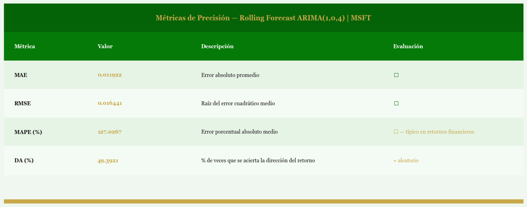

```python
import numpy as np
import pandas as pd
import matplotlib.pyplot as plt

plt.rcParams['font.family'] = 'Georgia'

# ── Colores ───────────────────────────────────────────────────────────────────
C_HEADER = '#046307'
C_SUB    = '#057a09'
C_ROW1   = '#e6f4e6'
C_ROW2   = '#f4fbf4'
C_GOLD   = '#c9a84c'
C_TEXT   = '#1a1a1a'
C_WHITE  = 'white'
BG       = '#f0f7f0'

# ── Cálculo de métricas ───────────────────────────────────────────────────────
errors   = actual_vals - forecast_vals
MAE      = np.mean(np.abs(errors))
RMSE     = np.sqrt(np.mean(errors**2))
non_zero = actual_vals != 0
MAPE     = np.mean(np.abs(errors[non_zero] / actual_vals[non_zero])) * 100
DA       = np.mean(np.sign(forecast_vals) == np.sign(actual_vals)) * 100

# ── Filas de datos ────────────────────────────────────────────────────────────
filas = [
    ('MAE',      f'{MAE:.6f}',  'Error absoluto promedio',                          '✓' if MAE  < 0.02  else '⚠'),
    ('RMSE',     f'{RMSE:.6f}', 'Raíz del error cuadrático medio',                  '✓' if RMSE < 0.02  else '⚠'),
    ('MAPE (%)', f'{MAPE:.4f}', 'Error porcentual absoluto medio',                  '⚠ — típico en retornos financieros'),
    ('DA (%)',   f'{DA:.4f}',   '% de veces que se acierta la dirección del retorno','✓' if DA   > 50    else '≈ aleatorio'),
]

# ── Dimensiones ───────────────────────────────────────────────────────────────
n_total = 1 + 1 + len(filas) + 1   # título + encabezado + filas + pie
rh      = 1 / n_total
fig_h   = max(5, n_total * 0.55)

fig, ax = plt.subplots(figsize=(13, fig_h), facecolor=BG)
ax.set_facecolor(BG)
ax.axis('off')
ax.set_xlim(0, 1)
ax.set_ylim(0, 1)

x_col = [0.02, 0.18, 0.38, 0.75]   # Métrica | Valor | Descripción | Evaluación

def draw_row(ax, row_idx, bg, cols, colors=None, bolds=None, fontsize=9.5, center=False):
    y_bottom = 1 - (row_idx + 1) * rh
    ax.add_patch(plt.Rectangle((0, y_bottom), 1, rh,
                 color=bg, transform=ax.transAxes, clip_on=False))
    for i, (txt, x) in enumerate(zip(cols, x_col)):
        ax.text(0.5 if (center and i == 0 and len(cols) == 1) else x,
                y_bottom + rh / 2, txt,
                transform=ax.transAxes,
                ha='center' if (center and i == 0 and len(cols) == 1) else 'left',
                va='center',
                fontsize=fontsize,
                color=(colors[i] if colors else C_TEXT),
                fontweight='bold' if (bolds and bolds[i]) else 'normal')

row = 0

# ── TÍTULO ────────────────────────────────────────────────────────────────────
y_bottom = 1 - rh
ax.add_patch(plt.Rectangle((0, y_bottom), 1, rh,
             color=C_HEADER, transform=ax.transAxes, clip_on=False))
ax.text(0.5, y_bottom + rh / 2,
        f'Métricas de Precisión — Rolling Forecast ARIMA({best_p},{best_d},{best_q}) | MSFT',
        transform=ax.transAxes, ha='center', va='center',
        fontsize=12, color=C_GOLD, fontweight='bold')
row += 1

# ── ENCABEZADO ────────────────────────────────────────────────────────────────
draw_row(ax, row, C_SUB,
         ['Métrica', 'Valor', 'Descripción', 'Evaluación'],
         colors=[C_WHITE]*4, bolds=[True]*4)
row += 1

# ── FILAS DE DATOS ────────────────────────────────────────────────────────────
for metrica, valor, desc, eval_txt in filas:
    bg       = C_ROW1 if row % 2 == 0 else C_ROW2
    e_color  = C_GOLD if '⚠' in eval_txt or 'aleatorio' in eval_txt else '#046307'
    draw_row(ax, row, bg,
             [metrica, valor, desc, eval_txt],
             colors=[C_TEXT, C_GOLD, C_TEXT, e_color],
             bolds=[True, True, False, False])
    row += 1

# ── LÍNEA DORADA INFERIOR ─────────────────────────────────────────────────────
ax.add_patch(plt.Rectangle((0, 0), 1, 0.018,
             color=C_GOLD, transform=ax.transAxes, clip_on=False))

plt.tight_layout(pad=0)
plt.show()
```